# 5-创建数据集

王梓安

2025-02-09

## 5.1 探索R中的数据结构

**数据集（不同类型的数据结构）**是进行数据分析的常见对象，通常是由**不同类型的数据**构成的一个矩形数组，行表示Case-观测（对象），列表示Variable-变量（属性）。

1.数据类型

数据类型相当于语法里的基本词汇结构，例如名词、动词、形容词……。常见的数据类型如下：

- 从统计学上来说，不同的数据类型可分为**连续变量、离散变量和称名变量（有序称名变量/无序称名变量）**。
- 在R中，这些数据类型又可以进一步细分为**数值型（连续变量/离散变量）、字符串型（因子）：有序称名变量/无序称名变量、逻辑型（TRUE/FALSE）、日期型、复数型（虚数）、原生型（字节）**。

2.数据结构

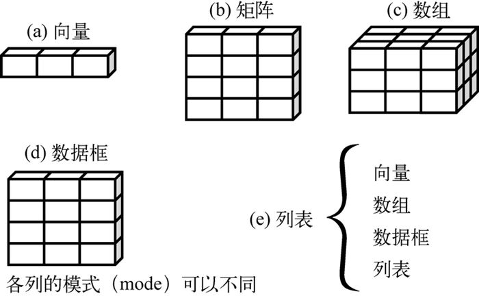

数据结构

数据集（不同类型的数据结构）就是由不同种类的数据“词汇”组成的词组。R中有许多用于存储数据的结构：**向量（标量）、矩阵、列表、数组（多维数组）、数据框**。

3.R对象

**R对象**可以是任何能被赋值的东西；对于R来说，对象可以是任何东西（数据、函数、图形、分析结果，等等）。

4.R中的数据结构

在R中，数据结构是一个比较宽泛的概念。比较标准的数据结构有：**向量（标量）、矩阵、列表、数组（多维数组）、数据框**；比较特殊的数据结构有：**因子（尽管因子严格意义上属于数据类型）、时间序列**……

### 5.1.1 向量

#### 1.向量的构成

**向量**是用于存储数值型、字符型或逻辑型数据的一维数组，类似于数学中集合的概念。执行组合功能的函数c()可用来创建向量。

由于向量是R中的基本数据结构，没有比他更小的结构，因此向量也可以看做是描述数据类型的单位：比方说，数值数据就是数值向量，因子（分类）数据就是因子（分类）向量。

在所有分析的数据对象中，最常分析的就是结构化数据的矩形数据（在R中一般对应数据框的数据结构），其每一列都是同一个变量、同样的数据类型。在R中，如果一列是表示的男女性别，那你就可以说这一列的数据类型是因子向量；如果一列表示是身高，那数据类型就是（连续型）数值向量……

```r
a <- c(1, 2, 5, 3, 6, -2, 4)
b <- c("one", "two", "three")
c <- c(TRUE, TRUE, TRUE, FALSE, TRUE, FALSE)
```

- 单个向量中的数据必须拥有相同的类型或模式（数值型、字符型或逻辑型）。同一向量中无法混杂不同类型的数据。
- **标量**是一种特殊的向量，其只含一个元素，例如f <- 3 、g <- “US” 和h <- TRUE 。它们用于保存常量。

R的基本数据结构是向量，而R里面的所有向量都是由标量组成的；在计算机语言中，X=1，Y=“男性”这种只有一个元素的对象都是标量。向量化编程是R的优势。

#### 2.向量的索引

```r
# 生成一个向量
help(package="datasets")
x <- c(2:101)
x
```

```r
# 正(负)整数索引

length(x)#计算向量中总共有几个元素
x[1]#访问向量中的第一个元素
x[0]#如果输入的是0，则是访问该向量中的第0个元素，但是因为向量正整数索引中只能从第一个开始，因此该索引是无效的
x[-9]#表示访问除了第9个元素以外的其他所有对象

x[c(4:18)]#只访问第4-18个的数值对象
x[c(7,8,9,6)]#只访问指定的数个对象
x[c(11,11,56,78,90)]#也可以重复访问向量里有的对象
x[c(1,2,-6)]#不可能既访问正数，也访问负数，不可能只输出1,2的同时又输出除了-6外的所有值，这是矛盾的
```

```r
# 逻辑索引
# 可以对向量里所有的对象赋予逻辑索引，这样可以对每个元素进行逻辑判断，为真的才可以输出

y <- c(1,2,3,4,5,6,7,8,9,10)
y
y[c(T,F,T,T,F,T,F,F,F,T)]
# 以上代码是只输出对应逻辑值为真（T）的值，y中FALSE位的值就不予输出

y[c(T)]
y[c(F)]
# 如果赋予向量的逻辑索引只包含一个元素，那就会对目标向量（比如y）的所有元素进行单一的逻辑判断：比方说对所有的y向量的值进行T赋值并输出，或者对所有的y向量的值进行F赋值并不予输出（因为R默认只会输出TRUE值）

y[c(T,F)]
y[c(T,T,F)]
# 如果逻辑索引向量的逻辑值元素数量少于要检测的目标向量的元素个数，就会按2个或3个一组进行if的循环判断，直到检测完目标向量的所有元素
y[c(T,F,T,T,F,T,F,F,F,T,T)]
# 如果逻辑索引的元素数量多于需要判断的目标向量的元素个数，就会出现NA值

# 还可以进行逻辑判断
y[y>5]
# 也可以通过大于小于的条件判断进行目标向量内部分元素的访问
y[y>5&y<9]
# 作用同上
```

```r
# 字符串索引（字符串的逻辑索引）


# 判断某个对象是否在向量z中
z <- c("one","two","three","four","five")
"one"%in%z
# 由于"one"%in%z是一个真命题，因此"one"%in%z等价于TRUE（真命题），因此z["one"%in%z]就等价于z[c(T)]，方括号是索引框，在此代码示例中，z["one"%in%z]和z[c(T)]的索引框中的内容是等价的
z["one"%in%z]

# 判断向量z是否在某个对象（向量c("one","two")）中，若有，则对应值输出为TRUE
z%in%c("one","two")
c("one","two")%in%z# 这个是对c("one","two")进行逻辑判断，告诉的是c("one","two")的值是否出现在向量z中

# 对向量z进行逻辑判断，看应该输出哪些值
k <- z%in%c("one","two")
# 再基于向量k进行逻辑判断：因为对象k进行逻辑判断的结果是z中只有两个字符串满足，因此z的索引框执行的结果是“one”、“two”（两个TRUE位置的值才能输出）
z[k]
```

```r
# 通过向量名称访问向量

y <- c(1,2,3,4,5,6,7,8,9,10)
names(y) <- c("one","two","three","four","five","six","seven","eight","nine","ten")
y# 第一行是向量名称，是向量的内部属性；第二行是向量元素的值，称为value
y["two"]
```

#### 3.向量的编辑

1. 增加

```r
# 添加单个元素
x <- c(2:101)
x[101] <- c(101)# 添加单个元素：对向量的第101个位置赋予101这个值
x

# 添加多个元素
v <- 1:3# 赋予向量v三个数值
v[c(4,5,6)] <- c(4,5,6)# 这里表示只赋值给第4,5,6个位置的对象
v
# 在第20个位置上添加6这个数据
v[20] <- 6# 这样操作，元素个数拓展到20个，但中间会有缺失值NA
v

# 在向量中插入新元素
# 这是专门在向量中插入数值的命令；如果在第0号位置后插入，实际上就是在第一个数值前插入的数据
append(x=v,values = 6,after=5)#在x这个向量的第5个位置后面插入一个99的元素
append(x=v,values = 6,after=0)#after=0则代表在向量的头部插入数据
```

2. 删除

```r
# 如果想删除整个向量，可以直接使用rm()函数；
# 如果想删除向量中特定对象，可以直接采用负整数索引的方式：

# 删除整个向量
y <- c(1,2,3,4,5,6,7,8,9,10)
rm(y)#这是直接删除整个向量

# 删除向量中特定对象
y <- c(1,2,3,4,5,6,7,8,9,10)
y[-c(1:3)]
y <- y[-c(1:3)]# 先用上面的命令删除1-3位置的元素，再将结果重新赋值给对象向量——其实就是重新生成一个新的向量，替换掉原来的向量
y
```

3. 修改

```r
v <- 1:3# 赋予向量v三个数值
v[c(4,5,6)] <- c(4,5,6)# 这里表示只赋值给第4,5,6个位置的对象
v[20] <- 6
v

# 修改比较简单：指定想要修改的元素在向量中的位置(或名称)，然后赋值即可
v[2] <- 100
v

# 不可以赋值字符串到数值向量中，不然整个向量都会变成字符型
v
class(v)
v[2] <- "one"
class(v)
```

#### 4.向量的计算

（1）数值运算

```r
# 1.向量和数值的运算
x <- 1:10
x <- x+1
x# 完成任何操作，都必须重新赋值，不然在R的环境中这个对象的内容还是操作之前的

# 2.向量和向量间的运算：向量间元素个数一致
x <- 1:10
y <- seq(1,100,length.out=10)
  # 向量内的元素分别相加或相乘
x+y
x*y
  # 两颗星号代表进行的是两个向量的幂运算(将两个向量的元素分别化为同底的幂进行的指数运算)
x**y
  # 求取除数、被除数间余数的运算
y%%x
  # 整除运算(只求除数、被除数的整数商，而不关注余数)
y%/%x

# 3.向量和向量间的运算：向量间元素个数不一致
x <- 1:10
z <- c(1,2)
  # 可以发现，当向量之间的元素个数不一致时，通常短向量会依次循环对长向量内的数值元素进行循环运算，直到算出结果
x+z
x*z
  # 当长向量和短向量不存在整数关系时，就会无法完成计算的循环，这样就会报错
x <- 1:10
g <- c(1,2,3)
x+g
```

（2）逻辑运算

```r
# 注意，所有基于逻辑符号的运算都是输出真假（TRUE/FALSE）的结果，如果要判断向量哪些值满足真假条件，需要将逻辑判断置于判断框[]内
x <- 1:10
y <- seq(1,100,length.out=10)

# 1.数值比较
# 用数值对向量元素进行判断，符合条件的则输出
x>5
x[x>5]
x>y
x[x>y]

# 2.字符比较
# 这个是用来判断包含算符左边的向量元素有多少是包含在右边的向量中的
c(1,2,3)%in%c(1,2,2,5,6)

# 3.判断是否相等
# 注意：判断两个向量是否相等只能用两个=，只用一个等于号是将向量y赋值给向量x
x==y
```

（3）向量计算的函数：数学函数

```r
# 用来取绝对值
z <- c(-5:5)
abs(z)
z <- abs(z)

# 用来取平方根
sqrt(z)
sqrt(25)

# 计算对数
# 16为要求的值，第二个参数base被视为底数，其对数就为4，即以2为底、16的对数
log(16,base=2)
# 没指明底数，默认是自然对数(以e为底)
log(16)
# 常见以10为底的对数，可以直接以10为底放前面
log10(10)
log2(16)

# 对向量x中的每个对象进行指数计算，即x中的每个整数都是以e为底的指数的幂指数计算：e的几次方
exp(x)

# 取整运算
# 取整运算：对向量进行判断，返回不小于向量中各元素的最小整数
ceiling(c(-2.3,-3.1415))
# 取整运算：floor命令返回不大于向量中元素的最大整数
floor(c(-2.3,3.1415))
# 取整运算：返回向量中元素的整数部分
trunc(c(-2.3,3.1415))
# 取有效小数：也是取整函数，但可以通过digits值来约束四舍五入到小数点后几位
round(c(-2.3,3.1415),digits = 2)
# 取有效数字：比如取2位，只有1位是有效数字被保留，其后面一位只是来进行四舍五入的评估而已
signif(c(-2.3,3.1415),digits = 2)

# 常见的三角函数
sin(6)
cos(6)
tan(6)
```

（4）向量计算的函数：统计函数

```r
# 计算函数
vec <- 1:100
vec
sum(vec)#求和函数
max(vec)#返回最大值
min(vec)#返回最小值
mean(vec)#求平均值
range(vec)#返回最大值和最小值
var(vec)#返回向量的方差
sd(vec)#返回向量的标准差
round(sd(vec),digits = 2)#返回标准差的同时，保留两位小数
prod(vec)#返回向量元素连乘的积
median(vec)#计算中位数
quantile(vec)#返回数值型向量中的分位数，默认是四分位数
quantile(vec,c(0.4,0.5,0.6))#具体的分位数值也可以自己指定

# 位置函数
t <- c(1,3,5,5,7,10,8,9)
which.max(t)#位置函数：这个返回的是最大值的位置
which.min(t)#位置函数：这个返回的是最小值的位置
which(t==5)#位置函数：这个返回的是t=5的值的元素的位置
which(t>5)#位置函数：这个返回的是t大于5的值的元素的位置
t[which(t>5)]#位置函数：这个返回的是t大于5的元素值；中括号[]里面表示目标对象内部元素的位置索引，这个位置可以直接指定，也可以通过which函数限制条件来表现
```

### 5.1.2 矩阵

#### 1.矩阵的构成

矩阵是一个二维数组，在R中，矩阵是有维数的向量，这里的矩阵元素可以是数值型、字符型或者是逻辑型，但是每个元素必须都拥有相同的模式，这个和向量一致。可通过函数matrix创建矩阵：

```r
# 这是一个代码模版，其中涉及的对象仅做填充物，在本笔记中并不指代具体的数据
myymatrix <- matrix(vector,
                    nrow=number_of_rows,
                    ncol=number_of_columns,
                    byrow=logical_value,
                    dimnames=list(
                    char_vector_rownames,
                    char_vector_colnames))
```

- 其中 vector包含了矩阵的元素，nrow和ncol用以指定行和列的维数，dimnames包含了可选的、以字符型向量表示的行名和列名。选项byrow则表明矩阵应当按行填充（byrow=TRUE）还是按列填充（byrow=FALSE），默认情况下按列填充。

```r
# 1.创建一个5×4的矩阵
y <- matrix(1:20, nrow=5, ncol=4)

# 2.创建一个2×2的含列名标签的矩阵
cells    <- c(1,26,24,68)
rnames   <- c("R1", "R2")
cnames   <- c("C1", "C2")
    # （以下2行）按行填充的2×2矩阵
mymatrix <- matrix(cells, nrow=2, ncol=2, byrow=TRUE,
                     dimnames=list(rnames, cnames))
    # （以下2行）按列填充的2×2矩阵
mymatrix <- matrix(cells, nrow=2, ncol=2, byrow=FALSE,
                     dimnames=list(rnames, cnames))

# 3.矩阵行列纬度和名标签的其他赋值方法
morematrix <- matrix(1:10, nrow=2, ncol=5, byrow=TRUE)
# （1）赋予矩阵行列纬名标签
  # 定义两个向量rnames、cnames，预设好行数、列数名称
rnames <- c("R1","R2")
cnames <- c("C1","C2","C3","C4","C5")
morematrix
  # 通过dimnames命令赋予名字给行、列
dimnames(morematrix) <- list(rnames,cnames)
# （2）赋予矩阵行列纬度
morematrix
# dim函数可以用来判断对象的纬度：有几个纬度就有几个数字
dim(morematrix)
# dim函数也可以用来快速给R对象赋予行列纬度：用向量指代行数、列数可以快速给R对象赋予纬度——就像这个例子中，R对象x被赋予了两个纬度，2行2列
dim(morematrix) <- c(5,2)
morematrix
```

#### 2.矩阵的索引

R中使用线性代数的i/j记号体系，i代表行号，j代表列号。如下述代码块所示，我们可以使用下标和方括号来选择矩阵中的行、列或元素：

（1）基于整数的索引

```r
m <- matrix(1:20,4,5,byrow = T)
m
m[1,2]#这个表示搜索的是第一行，第二列
m[1,c(2,3,4)]#第一行的第二、三、四列
m[c(2:4),c(2,3)]#这个相当于输出的矩阵的一个子集，第二行到第四行，第二列、第三列的部分
m[2,]#表示只访问第二行
m[,2]#表示只访问第二列
# 如果没有逗号，直接就是数字，那么访问的就是第几行的第一个数值(对象)
m[2]
m[3]
# 负号表示排除；因此这个矩阵输出的是除了第一行以外的第二列
m[-1,2]
```

（2）基于名称的索引

```r
# 也可以通过名称直接访问矩阵元素
m <- matrix(1:20,4,5,byrow = T)
Rnames <- c("R1","R2","R3","R4")
Cnames <- c("C1","C2","C3","C4","C5")
dimnames(m)=list(Rnames,Cnames)
m
m["R1","C1"]#用名称进行检索时，也要注意先行后列

# 下面以state.x77矩阵举例子：
head(state.x77)
state.x77[,"Income"]#还是一样的，输出整列需要前面有逗号
state.x77["Alabama",]#还是一样的，输出整行需要后面有逗号
```

#### 3.矩阵的计算

```r
# 注意：所有数据结构的运算，只是运算没有赋值的话就无法改变原来的结果


# 1.矩阵中的四则运算
m <- matrix(1:20,4,5,byrow = T)
m+1#所有要素都加1
m*2#所有要素都乘2
m+m

# 2.矩阵与矩阵的四则运算
m <- matrix(1:20,4,5,byrow = T)
n <- matrix(1:20,5,4)
m+n
# 注意：如果两个矩阵的行列数对不上，就会导致无法运算

# 3.取出部分矩阵的运算
# 如果想计算某行(列)的值，就需要将其单独赋值给新对象进行计算
m[1,]
t <- m[1,]
sum(t)
# 矩阵的运算大多数时候不需要只算出单独行列的值，也有可以对全行、列进行计算的函数
colSums(m)#计算每列的和
m
rowSums(m)#计算每行的和
m
colMeans(m)#计算每列的平均值
rowMeans(m)#计算每行的平均值

# 4.矩阵与矩阵的内积、外积运算
n <- matrix(1:9,3,3)
t <- matrix(2:10,3,3)
  # 这个类似向量的内积：矩阵内各个对应位置上的数值相乘
n*t
  # 这个类似向量的外积(具体作用见相关资料)：其应用意义为：
n%*%t
#（1）计算法向量：叉乘的结果向量垂直于原始向量A和B，可用于计算平面或多边形的法向量。
#（2）计算面积：两个向量的叉乘长度等于构成平行四边形的两边对应的向量所围成的平面区域的面积。
#（3）判断线性方向：叉乘的结果向量可以用来判断两个向量的相对方向：如果A x B的结果向量指向上，则A相对于B是逆时针旋转；如果结果向量指向下，则A相对于B是顺时针旋转。

# 5.矩阵的其他计算函数
  # diag函数,求出对角线处的元素值
n
diag(n)
  # t命令可以快速调转排列顺序，把按行排列改成按列排列
t(m)
m
```

### 5.1.3 数组

数组 （array）与矩阵类似，但是维度可以大于2，因此可以把数组看成是多维矩阵。数组可通过array 函数创建，形式如下：

```r
myarray <- array(vector, dimensions, dimnames)
```

- 其中，vector包含了数组中的数据，dimensions是一个数值型向量，给出了各个维度下标的最大值，而dimnames是可选的、各维度名称标签的列表。

```r
# 1.（和矩阵类似）先创立数组，再使用dimnames和dim函数分别赋予数组纬度和纬度名称
x <- 1:20
dim(x) <- c(2,2,5)#同时对一个数值型R对象的三个纬度规定数量，就形成了数组
anames <- c("A1","B2")
bnames <- c("B1","B2")
cnames <- c("C1","C2","C3","C4","C5")
dimnames(x) <- list(anames,bnames,cnames)
x

# 2.使用array函数直接赋予数据以数组的纬度和纬度名称
  ?array#如何同时做到规定数组内容的同时，规定好行、列、高度的数量和名称：array命令
# 首先和前面矩阵类似，先对预设的三个R对象（包含行、列、层名称）进行赋值，用字符串完成对3个字符串型向量的赋值(因为向量是R中的基础对象，构成R中的一切)
dim1 <- c("A1","A2")
dim2 <- c("B1","B2","B3")
dim3 <- c("C1","C2","C3","C4")
# 然后再基于这三个字符串向量组成的列表对象，完成对数组的赋名操作
z <- array(1:24,c(2,3,4),dimnames=list(dim1,dim2,dim3))
z

# 注意：
# 1）dim命令是用来给数组或矩阵赋予各个纬度的，dimnames命令则是用来赋予各纬度名称的
# 2）除了数值型数组，也有名称或逻辑型数组；同时，数组的纬度也不局限于三维；只是这样用到的情况比较少
```

- 数组是矩阵的一个自然推广，像矩阵一样，数组中的数据也只能拥有一种模式。从数组中选取元素的方式与矩阵相同，上例中，元素z[1,2,3] 为15。

### 5.1.4 列表

关于R中列表的定义：列表顾名思义就是用来存储很多内容的一个集合。在其他编程语言中，列表一般和数组是等同的，但是在R语言中，列表却是R中最复杂的一种数据结构，也是非常重要的一种数据结构——因为在R中，作为一些对象的有序集合，列表中可以存储若干向量、矩阵、数据框，甚至其他列表的组合，各个数据结构都可以存储在列表中。

R中列表有如下特征：

1. 在模式上和向量类似，都是一维数据集合。
2. 向量只能存储一种数据类型，列表中的对象可以是R中的任何数据结构，甚至列表本身。

#### 1.列表的构成

可以使用list()函数来创建列表：

```r
# 下面是一个包含了两个向量的列表示例——每个向量有50个元素：
state.center

# 下面是构建一个列表的过程：
a <- 1:20#这是一个向量
b <- matrix(1:20,4)#这是一个矩阵
c <- mtcars#这是内置的数据框
d <- "This is a test list"#这是一个标量
  # 通过list列表命令将各个R对象罗列到列表list中去
mlist <- list(a,b,c,d)
mlist
 # 可以通过"某某=a"的形式为列表里的各个R对象命名
mlist <- list(first=a,second=b,third=c,forth=d)
mlist
```

#### 2.列表的索引

```r
# （1）通过整数索引访问
mlist[1]#访问列表的第一个对象
mlist[c(1,4)]#访问列表的第一个、第四个对象

# （2）通过名称索引访问
state.center
state.center[c("x","y")]#直接通过向量访问名称

a <- 1:20
b <- matrix(1:20,4)
c <- mtcars
d <- "This is a test list"
mlist <- list(a,b,c,d)
mlist <- list(first=a,second=b,third=c,forth=d)
mlist[c("first","second")]#直接通过向量访问名称

# （3）使用$刀乐符访问
mlist$first#列表比之后的数据框多一种$的访问方式：名称可以接在$符号后面进而快速访问

# （4）使用双中括号的访问
# 两者的差别在于，一个中括号其实输出的是列表的一个子集，它其实还是一个列表，因为如果一个访问多个元素，这些元素的数据类型又不同，那么输出结果只能是列表；当我们使用两个中括号进行输出，那么就是输出数据本身的类型。
# 此外还要注意：两个中括号的格式输出的时候，只能输出一个对象。
mlist[1]
mlist[[1]]
class(mlist[1])
class(mlist[[1]])
```

#### 3.列表的编辑

```r
# （1）列表的赋值
# 明白上面的操作后，在进行列表赋值的时候，就得知道：
mlist[[5]] <- iris
length(mlist)
# 必须采用双重中括号，这样R才知道赋值给列表的新对象不是一个列表；如果使用一组中括号，就会发现R报错——因为R认为你赋值的应当是列表，而你实际赋值的是矩阵iris

# （2）删除列表中的对象
# 方法1：使用负索引删除后赋值给原列表
mlist[-5]
mlist <- mlist[-5]
# 方法2：直接将NULL值赋值给列表中的R对象即可；此处是对列表的对象而非子集进行操作，因此是双中括号
mlist[[4]] <- NULL
mlist
```

### 5.1.5 数据框

数据框的定义：

- 由于不同的列可以包含不同模式（数值型、字符型等）的数据，数据框的概念较矩阵来说更为一般。其概念类似于SAS、SPSS和Stata中看到的数据集类似，数据框将是你在R中最常处理的数据结构。
- 数据集通常是由数据构成的一个矩形数组，行表示观测，列表示变量。不同的专业对于数据集的行和列叫法不同。

数据框的特征：

1. 矩阵必须为同一数据类型；数据框每一列必须同一类型，每一行可以不同。
2. 数据框中，由许多向量构成数据框的列，每一列必须具有相同的长度，所以数据框是矩形结构，而且数据框的列必须命名：
   - 从列来看，每一列不算表头，就是向量(数据类型相同)；算上表头，每一列就是数据框
   - 从行来看，第一行表头就是字符型向量；其余每一行都是数据框

#### 1.数据框的构成

```r
state <- data.frame(state.name,state.abb,state.region,state.x77)
state
#能合并的前提是数据数量相同都是50个，且排列顺序一致(都是按单一方向排列的向量)
#因此想要在R中分析数据，将数据分成一个个向量再直接合并成数据框就可以方便分析了
```

#### 2.数据框的索引

##### （1）从整数索引访问

```r
# 数据框在单中括号内输出的时候，输出的依然是数据框，带有行名、列名
state <- data.frame(state.name,state.abb,state.region,state.x77)
state

# 正整数索引
state[1]#输出的第一列
state[c(2,4)]#输出的第二列、第四列
state[,c(2,4)]#输出的第二列、第四列(输出列时，加不加前面的逗号都行)
state[c(2,4),]#输出的第二、第四行

# 负整数索引
state[-c(2,4)]#将2、4列以外的列进行输出
state[-c(2,4),]#将2、4行以外的行进行输出
state
```

##### （2）从名称访问

1）通过中括号框

```r
state <- data.frame(state.name,state.abb,state.region,state.x77)
state
# 直接输出整列
state[,"state.abb"]
# 直接输出整行
state["Alabama",]
# 输出的时候注意行列的名称都是字符型，要加""双引号；
```

2）通过 `$` 符号快速访问(一列)

```r
state <- data.frame(state.name,state.abb,state.region,state.x77)
state
# 该方法可以快速取出一列
state$Murder
# 以R自带的women数据集为例，需要绘制散点图时，可以使用$符号快速生成图像的XY轴：
women
plot(women$height,women$weight)
# 同时在进行线性回归分析的时候，对行列名称的快速访问也非常重要：
lm(weight~height,data = women)
```

##### （3）快速访问多列数据的方法

```r
# attach函数和with函数
# （1）attach函数
# 可以使用attach()将数据集存进R的内存，这样就便于访问
attach(mtcars)
rownames(mtcars)
colnames(mtcars)
# attach函数加载好之后，就可以直接调用而不需要$符，包括下面的求每列、每行的和等
mpg
hp
cyl
# 使用完成后用detach命令结束调用就行了
detach(mtcars)

# （2）with函数
with(mtcars,{hp})
with(mtcars,{mpg})
with(mtcars,{sum(mpg)})
#本质上是在大括号里进行所有的操作
```

##### （4）使用双重中括号来访问

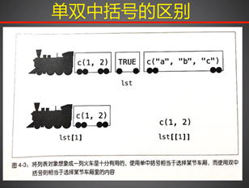

单双中括号的区别

```r
# 数据框也可以使用双重中括号来访问：
# 和列表类似，双中括号访问出来的都是向量而非数据框
mtcars
mtcars[[1]]# 索引出的是第一列的向量合集（不包括第一列的列名）
mtcars[[2]]
```

注意：两个中括号的格式输出的时候，只能输出一个对象。

### 5.1.6 特殊数据类型（结构）

#### 1.因子

##### （1）回顾：数据的类型

在数据科学中，常见的变量形式有数据型变量和分类型变量，进一步细分为：

1. 连续变量（数据变量）
2. 离散变量（数据变量）
3. 分类（称名）变量
   - 二分类变量（比较特殊）
   - 有序分类变量（比较特殊）

##### （2）因子的定义

因为因子的特殊性，必须说明：因子既是一种特殊的数据结构，也是一类特定数据类型（分类变量）的统称（至少在R中是这样的）。因此可以说，因子本身也是向量（数据结构）的一种，只不过其包含的元素（分类变量元素）可以用来分类。

**因子：在R中，称名变量和有序型变量（统称分类变量）称为因子`factor`。这些分类变量的可能值称为一个水平(level)，例如good，better，best，都称为一个level**。由这些水平值构成的向量就称为因子。

##### （3）因子的作用

因子的最大一个作用就是用来分类并统计不同分类对应的频数和频率。

注意：从上述的描述可以看出，因子只是一个概念，包含名义型、有序型变量，同时也是一种数据结构。此外，**因子的单位是level，一个level包含一种分类变量**——比如一份表格包括多个省份，相同的省份聚集产生一个level，所有level的集合才能表达这类level的共同的数据类型：（代表不同省份的）因子。

##### （4）示例：因子的使用——统计各分类的频数、频率

```r
# 以mtcars矩阵为例
?mtcars
# 观察说明后发现，cyl列属于因子类型数据(可以用来分类)；
mtcars$cyl#在table函数中进行因子分类
table(mtcars$cyl)
# 得到结果分为三类4、6、8；其中，4、6、8各自为一种level；
```

##### （5）因子的构成

- 因子的输出

```r
# 输出因子数据
f <- factor(c("red","red","green","blue","green","blue","blue"))
f#以因子形式输出的数据会自动总结出有几种level

# 输出因子数据：希望是有序level
week <- factor(c("Mon","Fri","Thu","Wed","Mon","Fri","Sun"))
week#以默认的形式输出因子，你会发现，尽管R会给你规划出level种类，但是当你希望其为有序型因子时，其顺序默认不会给你总结；除非执行如下命令
week <- factor(c("Mon","Fri","Thu","Wed","Mon","Fri","Sun"),ordered = T,levels =
c("Mon","Tue","Wed","Thu","Fri","Sat","Sun"))
week#将ordered改成T之后，就可以编辑不同level之间的顺序
```

- 向量转化为因子

```r
# 同样使用factor命令将向量转化为因子数据结构
fcyl <- factor(mtcars$cyl)
fcyl
plot(mtcars$cyl)
plot(factor(mtcars$cyl))
# 向量转化为因子后，plot函数在绘图时，向量绘制的就是散点图；因子绘制出来的就是柱状图
```

##### （6）因子的分割

```r
# 可以将向量等其他形式的数据分割成因子的形式，方便观察有几个level
num <- 1:100
num
cut(num,c(seq(0,100,10)))#seq是等差数列的意思
num#cut命令只是方便你观察哪些数值在哪个分组而已
num <- cut(num,c(seq(0,100,10)))
num
```

#### 2.时间序列数据（日期和时间）

在R中，时间序列数据既是一类特殊的数据结构——时间序列在R中是一种专门的对象、简写为TS（TimeSeries）。同时，时间序列数据也是一种特定的数据类型（有序离散变量）：在R中，日期数据被单独归为一个date类。

时间序列数据的主要作用如下：

1. 对时间序列的描述
2. 利用前面的结果进行预测

R中有关时间序列数据的基础操作如下：

1. 使用sys.date()函数查看当前系统的时间
2. 使用as.date()函数将数据转换为日期数据：使用format选项参数决定外观（比如哪部分作为年，哪部分作为月）

##### （1）时间序列的定义

时间序列数据的性质和因子数据的性质很像，它们都不是由数据结构（向量、矩阵、数据框……）决定的数据类型，而是尤其自身的特殊作用决定的数据类型：

- 比方说，因子基本上都是用来分类、因为其分类的作用，单独区分出因子这种数据。同样的，时间序列数据在数据分析中承担的作用和一般的有序离散数据也不一样，因此需要单独区分出来。
- 同样的还有地理信息数据……这些数据即使经过结构化处理之后，依然显著区别于其同类型的一般数据（时间序列数据承担的作用显著区别于一般的离散数据），因此需要单独学习。

**严格来说，时间序列（日期）在R中应当看做数据类型而非数据结构，因子数据也是同理**：在R中，日期时间被归为一个单独的date类，它作为基本单位，和数值、字符串有本质上的区别。

##### （2）时间序列的识别

从下面的例子可以看出，时间序列数据虽然在R中是单独的数据类型，但是其常常和别的数据类型混搭形成特定的数据结构，因此把包含日期信息的特定数据结构统称为时间序列数据结构。

```r
# 识别的格式为TS，代表time series
presidents
class(presidents)

# 但是在R中表示时间序列的不只有TS一种格式，data.frame也是一种格式。
# airquality就是以数据框的形式表达TS的数据集：
airquality
class(airquality)

# 下面的时间序列就是美国公交客迎里程的时间序列，是一种比较特殊的TS格式，标注了时间起始点和终止点，数值则单独列出，这种非常适合一个时间点对应一个数据的情况。
airmiles
# 一般的时间序列格式是以列表的形式表现，airmiles比较特殊，是以专门的格式表现的。
```

如何查看系统的时间：

```r
# 使用sys.date()函数查看当前系统的时间
Sys.Date()#这在R中可以直接查看系统当前时间；
class(Sys.Date())#对于基本的时间对象，其属性显示为Date时间，但是，其对应的数据结构可以是TS、数据框、列表等等。
```

##### （3）时间序列数据的转化与生成

```r
# 1.使用as.date()函数将字符串数据转换为日期数据
a <- 2024-01-01
as.Date(a,format="%Y-%m-%d")#将字符串转化成时间序列
a
class(a)#此时a还是数值
a <- as.Date(a,format="%Y-%m-%d")#Y表示2017，y表示17；后面m、d的大小写区别同理
a
class(a)
?strftime

# 2.生成时间序列数据
# （1）使用seq等差数列命令创建连续的时间点
seq(as.Date("2017-01-01"),as.Date("2017-07-05"),by=5)
# 在seq函数中套as.Data函数，R就知道是时间，就不会产生2.30号这样的错误

# （2）使用ts函数将向量（数值）数据转化为时间序列数据
?ts#将向量转化成时间序列(在原有向量基础上进行匹配生成时间序列)
sales <- round(runif(48,min=50,max = 100))#使用round函数配合runif函数进行随机数值的生成，round表示取整，runif表示生成的个数、范围等等

ts(sales,start=c(2010,5),end=c(2014,4),frequency = 1)
ts(sales,start=c(2010,5),end=c(2014,4),frequency = 12)
ts(sales,start=c(2010,5),end=c(2014,4),frequency = 4)
# 利用ts函数将时间序列和数据进行匹配，赋原始数据以时间属性，frequency设置的值有1、12、4，分别代表按年划分、按月份划分、按季度划分（没有按分钟划分的）
```

### 5.1.7 数据结构中的特殊数据类型

#### 1.缺失数据NA

##### （1）缺失数据的分类

我们使用sleep研究中对做梦时长的测量（有12个动物有缺失值）来依次阐述三种类型：

1）完全随机缺失

若某变量的缺失数据与其他任何观测或未观测变量都不相关，则数据为完全随机缺失（MCAR） 若12个动物的做梦时长值缺失不是由于系统原因，那么可认为数据是MCAR。

注意：如果每个有缺失值的变量都是MCAR，那么可以将数据完整的实例看做是对更大数据集的一个简单随机抽样。

2）随机缺失

若某变量上的缺失数据与其他观测变量相关，与它自己的未观测值不相关，则数据为随机缺失（NLAR）。例如，体重较小的动物更可能有做梦时长的缺失值（可能因为较小的动物较难观察），“缺失”与动物的做梦时长无关，那么该数据就可以认为是MAR。

此时，一旦你控制了体重变量，做梦时长数据的缺失与出现将是随机的。

3）非随机缺失

若缺失数据不属于MCAR或MAR，则数据为非随机缺失（NMAR）。例如，做梦时长越短的动物也更可能有做梦数据的缺失（可能由于难以测量时长较短的事件），那么数据可认为是NMAR。

##### （2）缺失数据的原因

1. 机器断电，设备故障导致某个测量值发生了丢失。
2. 测量根本没有发生，例如在做调查问卷时，有些问题没有回答，或者有些问题是无效的回答等。

##### （3）R中的缺失数据NA

在R中，NA代表缺失值，NA是不可用、not available的简称，用来存储缺失信息。

这里缺失值NA表示没有，但注意没有并不一定就是0，NA是不知道是多少，也能是0，也可能是任何值，缺失值和值为零是完全不同的。

##### （4）R中处理缺失数据的方法

```r
# 在R中，缺失值会原封不动地被保留和传输：
NA+1
NA==0
# NA加任何值都是NA，NA判断是否等于0，结果也是NA，其性质和无穷有点像，
# 任何有意义的数值和NA产生关系得到的结果都是NA


# 如下，如果一个庞大的数据集仅仅因为NA值就无法计算，就需要解决方法：
a <- c(NA,1:49)
a
sum(a)
mean(a)
# 此时，调用na.rm函数并设置为TRUE即可解决问题；你会发现，该函数不仅在运算中可以忽略NA的数值，将NA去除的同时，也会将NA值的个数去除，例如在计算平均值时，就会以n=49而非n=50计算
sum(a,na.rm = TRUE)
mean(a,na.rm = TRUE)
```

##### （5）如何测算出哪里有NA值

```r
# 方法一：使用is.na函数
# 上面的na.rm函数的使用前提必须是你知道有没有NA值；那么如何知道呢？
is.na(a)
# 使用is.na函数，可以检验对象是否有NA值，TRUE返回的就是NA值所在的地方；
# install.packages("VIM")
library(VIM)
sleep
is.na(sleep)

# 方法二：使用行列计算侧面反映
# 有时也可以通过行列总和的计算侧面反映出哪里有NA值
colSums(sleep)
rowSums(sleep)
```

##### （6）如何删除（修改）NA值

```r
# (1)向量
# 使用na.omit函数可以方便的去除向量中的NA值
?na.omit
c <- c(NA,1:20,NA,NA)
c
d <- na.omit(c)
d
is.na(d)#检测是否还有缺失值

# (2)数据框的NA值去除
na.omit(sleep)
length(rownames(sleep))
length(rownames(na.omit(sleep)))
# 但是na.omit命令问题也很多，当其对数据框执行命令时，它会把有NA值的行全部删除，这对统计有时会造成严重的影响。
```

**关于不同类型的NA值该如何处理，请专门进行学习**。

##### （7）R中其他类型的缺失数据

1、缺失数据NaN

2、inf无穷

分为正无穷inf和负无穷inf，代表无穷大或者无穷小

3、不同缺失值的区别

- NA是存在的值，但是不知道是多少；
- NaN是不存在的；
- lnf存在，是无穷大或者无穷小，但是表示不可能的值；

```r
1/0#Inf
-1/0#-Inf
0/0#NaN
```

4、如何识别NAN值和无穷值inf

```r
is.nan(0/0)
is.infinite(1/0)
```

#### 2.字符串数据

在R中，字符串出现的地方一定要加引号”“，对应的，R中也有专门处理字符串的函数，其大多支持正则表达式。

##### （1）nchar函数（计算字符数量）

```r
# nchar函数统计的是字符串对象的字符数量；注意，空格也算是一个字符。
nchar("Hello World")

# 注意，nchar命令和length命令都是统计数量的，不同在于，nchar统计一个R对象里所有个体(字符串)各自的长度，并分别呈现；但length命令测量的是一个R对象里不同个体的个数
month.name#这是一个包含月份名称的字符串向量
nchar(month.name)
length(month.name)

# 当然，nchar也可以处理数值型向量，本质上就是把数值转化成了字符串
nchar(c(12,1,123))
```

##### （2）paste函数(用于合并字符串)

```r
# paste函数：用于合并字符串，将多个字符串合并为一个
paste(c("Everybody","loves","stats"))
paste("Everybody","loves","stats")
# paste命令关于向量的用法：在括号里面，单独的对象被逗号分割开，因此想要粘合n个对象，就需要n-1个逗号。第一行之所以结果不对，是因为逗号在括弧里，c后面表示的向量在paste命令看起来是一个整体。

paste("Everybody","loves","stats",sep = "-")
# 得到的结果默认是使用空格连接，可以使用sep命令改成其他符号来连接；

names <- c("Moe","Larry","Curly")
paste(names,"loves","stats")
# 如果将一个向量和两个单独的字符进行粘合，其结果就是向量内部的对象分别和外部的字符进行匹配粘合；
```

##### （3）substr函数(用于提取字符串)

```r
# substr函数：用于提取字符串——函数的参数分别是一个原始的字符串，一个起始点和一个结束点，返回值是起始点和结束点之间的字符串
substr(x=month.name,start = 1,stop = 2)#运行对比一下就知道了
substr(x=month.name,start = 1,stop = 3)

# substr可以快速捕捉R对象中字符串个体的部分，start和stop分别对应提取起始点和结束点
temp <- substr(x=month.name,start = 1,stop = 3)
toupper(temp)#将字符串全部转成大写字母
tolower(temp)#将字符串全部转成小写字母
```

##### （4）gsub函数

```r
# 通过正则表达式，可以只改变首字母大小写；U对应大写，L对应小写
gsub("^(\\w)","\\U\\1",tolower(temp))
gsub("^(\\w)","\\U\\1",tolower(temp),perl = T)
gsub("^(\\w)","\\L\\1",tolower(temp),perl = T)
```

##### （5）grep函数(可以用于查找字符串)

```r
# grep函数：支持字符串和正则表达式的匹配
x <- c("b","A+","AC")
grep("A+",x,fixed=T)
grep("A+",x,fixed=F)
# 第一个表示需要识别的对象，第二个表示进行识别的范围；第三个参数影响的是识别的规则，为T，则将需要识别的对象看做字符串，此时只有和对象完全一致的对象的位置才会被表示出来；为F，则识别对象看成正则表达式，此时A+表示以A开头的任何字符串，因此AC也会被识别。
```

##### （6）match函数（可以进行字符串匹配）

```r
# match函数：match函数就只会将对象看做字符串，没有正则表达式的功能
match("AC",x)
```

##### （7）strsplit函数（进行字符串的分割与连接）

```r
# 使用分割命令时，既要有分割对象，也需要设置分割符号，要不然无法分割；
# 分割命令产生的结果是列表不是向量，因为产生的控制符串""既是字符也是向量。
path <- "/user/local/bin/R"
strsplit(path,"/")

# strsplit命令（分割）
strsplit(c(path,path),"/")
# 为什么分割字符串的命令返回的是列表而不是向量呢？因为这个命令通常同时对好几个字符串型向量进行分割，此时就是一个大向量里包含多个小向量的情况，向量里又有字符串，非常复杂，因此列表形式返回更方便

# outer命令（连接）
face <- 1:13
suit <- c("spades","clubs","hearts","diamonds")
face
suit
outer(suit,face,FUN = paste)
outer(suit,face,FUN = paste,sep="-")
# outer函数可以执行两个字符串向量直接的连接问题，其以列表形式输出，FUN命令调用paste进行连接，sep接paste命令后补充说明连接符是什么。
```

## 5.2 创建含有研究信息的数据集

**按照个人要求的格式来创建含有研究信息的数据集，这是任何数据分析的第一步**。

在R中，这个任务包括以下两步：

- 选择一种数据结构来存储数据（详见 5.1）
- 将数据输入或导入到这个数据结构中（详见 5.2.1 & 5.2.2）

输入和导入数据集的方法应该根据自己的需求进行有选择的学习，想用什么就学什么。

### 5.2.1 输入数据

#### 1.文本文件读入

##### （1）纯文本文件

纯文本文件，常见的尾缀为`.csv`和`.txt`：其中，不同列之间用空格进行分割，一般是.txt作为扩展名；使用逗号分割的，以.csv作为扩展名。读取这两类文件，最常用的命令是read.table命令：

```r
read.table(file = 要读入的文件的名称,
           sep = 指定文件使用的分隔符（默认是空白分割）,
           header = 代表在读取数据之后是否将数据的第一行作为变量的名称，而不是当成具体的值来处理，如果是，header=T，不是，header=F,
           skip = 表示读取参数时，跳过部分内容，比如说可以跳过一些介绍性文字,
           nrows = 用于读取文件的行数,
           na.strings = 用于处理缺失值的信息)
```

###### 1）文件读取路径（file参数）

read.table函数需要在工作目录下才可以直接输入名称，可以先用getwd命令查看一下当前Workspace的路径；如果不在工作目录下，可以利用setwd()函数来更改R的工作目录，或者使用文件的全路径：

```r
read.table("F:/R-File/input.txt")#文件不在设置的工作路径下，就需要以全路径的方式输入
read.table("input.txt")#文件在设置的工作路径下，可以直接从工作路径的下一级开始
read.csv("input.csv")#对于csv文件，如果提前知道文件格式，也可以直接用read.csv()进行直接读取
getwd()
read.table("input.txt")
x <- read.table("input.txt")#读取之后最好将文本文件赋值给一个对象，方便后续操作
```

###### 2）预览文件前几行（后几行）

```r
# 可以使用head()和tail()函数读取文件的前几行或者是后几行数据，可以通过函数中选项参数n的数值来确定显示的行数

head(x)#截取文档头部六行(默认)
tail(x)#截取文档尾部六行(默认)

head(x,n=10)#通过n来改变显示的头部、尾部的行数
tail(x,n=10)
```

###### 3）导入时的参数设置

`分隔符、表头处理、跳过命令、行数数量命令、na.strings参数和stringAsFactors参数`

分隔符的设置（sep参数）

- 如果是TXT文件以空格进行分割的，就可以直接导入；如果是CSV文件，其一般是以逗号分割的，直接导入会显示混乱：因为read.table命令默认的分隔符是空格。
- **所以读入文件之前，最好看一下文件是用什么符号分割的(直接记事本打开)**。

```r
# 分隔符
read.table("input.csv")
read.table("input.csv",sep=",")
```

关于表头的处理（header参数）

- header决定是否将表头当成变量来处理：为TRUE值，则设置表头为变量名称的属性；如果按照默认的F值来，就是将表头也当成变量了，这是要避免的。

```r
read.table("input.csv",sep = ",",header = TRUE)
```

读取任意部分的数据：跳过命令和行数数量命令（skip和nrows参数）

```r
# 像input 1这个文件中，文件前五行是对文档的描述，这在分析的时候对R是干扰，因此可以使用skip进行跳过(注意，跳过之前要看一下文件的前面哪几行要跳过)
read.table("input 1.txt",header = TRUE,skip = 5)

# 使用skip和nrows两个参数相结合，就可以读取任意部分的数据，比如读取上述文件第10-50行数据：
read.table("input 1.txt",header = TRUE,skip = 10,nrows = 50)
```

na.strings参数

```r
# read.table中的子命令；因为一般下载的文本格式会有缺失数据，但是其缺失数据的表述和R认可的不一致，需要通过这个命令将文件的缺失文件改成R可以识别的NA形式。
```

stringAsFactors参数

```r
# read.table中的子命令；用来控制读入的字符串是否转化成因子，R在读取数据时，数字会被读取成数值型数据，但读取字符串时，R会默认将所有的字符串转换成因子类型，但是很多情况下不需要这样的转换，所以需要将stringAsFactors设为TRUE。
```

###### 4）读取文本文件的其他注意事项

关于read.table命令的更多用法

```r
?read.table#更多函数使用？进行查阅
```

关于fwf格式文件的读取

```r
# 注意：fwf格式文件比较特殊，最好使用read.fwf(针对不同纯文本文件的特化简化版本)进行读入操作。

read.fwf("fwf.txt",widths = c(2,3,4))#需要在widths参数中给出每一列所占用的宽度值
read.fwf("fwf.txt")#这种文件比较少见，其好处就是处理后每列都非常对齐，看着很舒服
```

##### （2）网页上的纯文本文件

如何读取网络中的文本文件？

```r
# 如果一个纯文本文件并不在本机上，R可以支持读取网络文件，可以通过一些协议进行读取，只要将read.table()函数的选项参数file=文件的网络链接即可。R会将文件下载到本地。

x <- read.table("https://codeload.github.com/mperdeck/LINQtoCSV/zip/master",header=TRUE)
```

##### （3）如何读取网页上的非文本文件

对于网页非文本文件，我们可以使用XML包进行读取，里面包含一个readHTMLTable()函数，可以用于读取网页中的数据。

```r
# HTML中的表格
# install.packages("XML")
library(XML)
?readHTMLTable#可以使用group或sf函数来进行筛选

?XML#想要详细了解的具体查看包的相关注解，但是网页的表格文件通常不规则，很难被读取；
# 只是读取网页中的表格数据,可以设置which参数
readHTMLTable("https://en.wikipedia.org/wiki/World_population",which=3)#which设置为3，表示是第三个表格
```

#### 2.其他类型文件读入

##### （1）导入其他统一软件格式的数据(SPSS等)

R中的foreign包可以帮助导入其他软件的数据。但是，在有条件直接导出为CSV、TXT等文本文件的基础上，最好就直接导出成文本数据，直接用read.table读取。

```r
help(package="foreign")
# 如果遇到的文件用以上方法都读取不了的，可以：

# 1、将文件导出为文本文件；2、下载对应的包

# 例如想要处理matlab格式的文件就可以使用RSiteSearch函数进行搜索
RSiteSearch("Matlab")
# install.packages("Find matlab path")
```

##### （2）R读取剪切板的数据和压缩包数据

R可以直接导入剪切板的内容，直接将read.table()函数选项参数改为clipboard即可：

```r
# 1.读取剪切板
x <- read.table("clipboard",header=T,sep="\t")
x
#那么问题来了，clipboard是专有名词，如果恰巧有个文件也叫这个，该怎么办？可以使用file="clipboard"进行确认，但我觉得这个方法很傻逼，为什么不直接重新命名文件？或者也可以使用readClipboard函数直接读取
readClipboard()
a <- readClipboard()
a

# 2.读取压缩包
# 如果文件是压缩包的形式，比如gz、rar等，也可以直接读取
read.table(gzfile("input.txt.gz"))
```

##### （3）不标准的文件格式该如何处理呢？

```r
# readlines函数
?readLines#读取文件中各行并以字符串形式返回结果
readLines("input.csv",n=15)
readLines("input.csv",n=5)#通过设置参数n来限制读入的最大行数

# scan函数
?scan#每次读取一个单元，并根据指令进行处理；scan函数可以重复执行指定的模式直到读取所有需要的数据
scan("scan.txt",what=list(character(3),numeric(0),numeric(0)))
scan("scan.txt",what=list(X1=character(3),X2=numeric(0),X3=numeric(0)))
# what指数指定读写数据的类型是数值型、整形、字符型还是逻辑型；决定了你在文件中读取的数据种类。
```

### 5.2.2 输出数据

#### 1.write函数

对于简单的文本文件的输出，直接使用write函数即可：

```r
?Write
?cat
x <- rivers
cat(x)#cat是把结果显示到屏幕上，write是把结果写入到文件
write(x,file="x.txt")
```

#### 2.write.table函数

对于复杂的文本文件的输出，我们需要用到write.table函数：

```r
write.table(x=写入的数据,
            file=数据的存储路径及格式,
            sep=连接符)
```

下面是使用实例：

```r
?write.table
x <- read.table("input.txt",header=T)
write.table(x,file = "F:/R-File/anotherfile.txt")
# 可以使用sep改变分隔符为","，这样一来文件输出的尾缀也要改成csv；csv更加适合Excel打开，因为Excel可以识别制表符（对于txt文件，Excel不识别空格，会将一行内容挤到一个格子里）。
write.table(x,file = "F:/R-File/anotherfile.csv",sep = ",")

# 在写入CSV的时候，R默认会在第一列加行号，如果不禁止R的这个行为，对一个文件反复读取后就会出现多列行号，设置row.names=FALSE可以避免该情况。原文件自带的行号无法处理。
write.table(x,file = "F:/R-File/anotherfile.csv",sep=",",row.names=FALSE)

# 在写入TXT时，R默认会将字符串加上双引号，可以设置quote=FALSE来去掉这些双引号。
# 对于TXT、CSV两种格式的文件，在write.table函数里都可以通过设置na值来改变缺失值的符号表示
write.table(x,file = "F:/R-File/anotherfile.txt",quote=FALSE)

# R会覆盖同名文件，可以设置append参数为TRUE添加同名参数，从而保证在原文件后面直接续上表格内容；
# 注意：续表导出（单独调用append参数）也会默认加行号，因此得使用row.names命令去除行号；
write.table(iris,file = "F:/R-File/anotherfile.csv",sep=",",append=TRUE,row.names = FALSE)

# R也可以直接写成压缩文件
write.table(mtcars,gzfile("NEWfile.txt.gz"))#gzfile("NEWfile.txt.gz")表示输出压缩文件的格式(文件的名称)。注意，最好文件的名称和前面参数设置的格式（例如，gzfile对应.txt.gz）保持一致。
```

### 5.2.3 Excel和R格式文件的读写

#### 1.Excel读写

```r
# 可以使用两种方式进行简单读写：

# 1.将excel文件另存为csv文件，再使用read.csv()打开，如:
x <- read.csv("mtcars.csv",header = TRUE)
x

# 2.或者将数据复制到剪贴板，使用read.clipboard()函数将数据导入R中，在R中打开：
y <- read.table("clipboard",sep = "\t",header = T)#/t的连字符是要试出来的，不是每个软件都一样的；
y
# 如果Excel可以直接导出文本文件（Excel文件中只有一个sheet），就可以使用以上方法。
```

但是如果Excel文件里有多个工作表时，一个个导出就非常麻烦，这时就需要别的包；

##### （1）XLConnect包

```r
# 这个要安装JAVA依赖环境，比较烦，后面有需要再说
# install.packages("XLConnect")
library(XLConnect)


# 一、两步法读取
# 载入XLConnect包之后，先使用loadWorkbook赋值整个文件给ex，再用readWorksheet分别查看一个文件下不同工作薄
ex <- loadWorkbook("data.xlsx")
readWorksheet(ex,1)
# 读取之后赋值给数据框对象，单一对象的形式非常适合R处理
?readWorksheet
edata <- readWorksheet(ex,1)
head(edata)
# startRow/startCol/endRow/endCol这4个参数是XLConnect包控制读取范围的关键
# startRow/startCol控制起始单元格，endRow/endCol控制终止单元格
# header表示是否将表头作为数值读取，不想作为数值读取的设置为TRUE
readWorksheet(ex,1,startRow=0,startCol=0,endRow=50,endCol=3,header=TRUE)


# 二、一步法读取
?readWorksheetFromFile#data.xlsx表示文件名称，1表示工作簿的名字
readWorksheetFromFile("data.xlsx",1)


# 三、四步法写入（输出）
wb <- loadWorkbook("file.xlsx",create=TRUE)#首先创建一个文件
createSheet(wb,"Sheet 1")#创建一个工作簿
writeWorksheet(wb,data=mtcars,sheet="Sheet 1")#利用writeWorksheet函数将数据保存到工作簿中
saveWorkbook(wb)#将文件保存为xlsx或xls即可


# 四、一步法写入（输出）
writeWorksheetToFile("File1.xlsx",data=iris,sheet="Sheet 1")
# 上述命令可以按照列表格式一次输入多个工作簿到一个文件中
# 上述函数中，第一个值代表文件名，第二个值代表数据源，第三个值代表工作簿名称，也可以使用startRow/startCol/endRow/endCol这4个参数来控制读取范围


# 详细内容通过这个命令查看包的相关作用
vignette("XLConnect")
```

##### （2）xlsx包

```r
library(xlsx)
# 这个包用来进行Excel文件的简单读写，同样需要JAVA环境
help(package="xlsx")

# 读取
# 这个的逻辑和read.table比较像，第一个文件名，第二个工作簿的顺序，第三个、第四个开始结束的行
x <- read.xlsx("data.xlsx",1,startRow=1,endRow=100)

# 输出（写入）
# 第一个表示数据源，第二个表示文件名，第三个表示工作簿，最后一个表示F追加补充（T表示覆盖原来的文件）
write.xlsx(x,file="rdata.xlsx",sheetName="Sheert 1",append=F)
```

#### 2.R格式文件的读写

存储为R文件会有很多优势，R会对存储为内部文件格式的数据进行自动压缩处理，并且会存储所有与待存储对象相关的R元数据。如果数据中包含了因子，日期和时间或者类的属性等信息，使用R文件就更加方便了。

.rds文件保存单个对象(表格、数据框啥的)，.Rdata文件保存了environment里的变量，.R保存了代码(脚本)，三者共同构成了R project。

##### （1）rds文件(保存R的单个对象)

```r
head(iris)
# 写入（输出）
saveRDS(iris,file="iris.RDS")#第一个表示对象，第二个表示存储路径，如果在默认路径下存储，只输入文件名即可

# 读取
x <- readRDS("iris.RDS")#或者直接双击文件即可，这个读取其实没必要通过命令来完成。
x
```

##### （2）.Rdata文件(保存了environment里的变量)

```r
# 载入这个最好以命令的形式，反而.R的文件可以直接打开


# 加载
load(".RData")#但是这类文件打开一定要小心，尤其是在当前正在进行的project中，打开新的数据后，相同命名的对象就会覆盖当前已有的对象


# 保存
# 使用save命令可以有选择地保存确定的部分对象到一个新的.Rdata文件中去
save(iris,iris3,file="c:/Users/Desktop/iris.Rdata")
```

## 5.3 标注数据

创建数据集后，往往需要对它进行标注，也就是为变量和变量代码添加描述性的标签。

为了使结果更易解读，数据分析人员通常会对数据集进行标注。这种标注包括：

1.变量（名）标签：为变量名添加描述性的标签

2.值标签：为类别型变量中的编码添加值标签

例如，关于变量（名）标签，对于变量（名）age，你可能想附加一个描述更详细的标签“Age at hospitalization(in years)”（入院年龄）。

再比如，关于变量下属的值，也需要打上值标签；例如，对于编码为1或2的性别变量gender，你可能想将这个二分变量的两个值分别关联到标签“male”和“female”上。

### 5.3.1 变量（名）标签

遗憾的是，R处理变量标签的能力有限。一种解决方法是将变量标签作为变量名，然后通过位置下标来访问这个变量。举一个有关病例数据框的例子——名为age的第二列包含着个体首次入院时的年龄，代码如下：

```r
names(patientdata)[2] <- "Age at hospitalization (in years)"
```

如果将age 重命名为“Age at hospitalization (in years)”，很明显，新的变量名太长，不适合重复输入。作为替代，你可以使用patientdata[2]来引用这个变量，而在本应输出age的地方输出字符串”Age at hospitalization (in years)“。很显然，这个方法并不理想，如果你能尝试想出更好的命名（例如，admissionAge）可能会更好一点。

### 5.3.2 值标签

函数factor() 可为**类别型变量**创建值标签。继续上例，假设你有一个名为gender的变量，其中1表示男性，2表示女性。你可以使用代码来创建值标签：

```r
patientdata$gender <- factor(patientdata$gender,
                             levels = c(1,2),
                             labels = c("male", "female"))
```

这里levels代表变量的实际值，而labels表示包含了理想值标签的字符型向量。